# P4 Explore and Summarize Data

M.J. van der Poel

April 11th 2017

# Red Wine Quality

This tidy data set contains 1,599 red wines with 11 variables on the chemical properties of the wine. At least 3 wine experts rated the quality of each wine, providing a rating between 0 (very bad) and 10 (very excellent).

The guiding question in this investigation is Which chemical properties influence the quality of red wines?

Input variables (based on physicochemical tests):  
1 - fixed acidity (tartaric acid - g / dm^3)  
2 - volatile acidity (acetic acid - g / dm^3)  
3 - citric acid (g / dm^3)  
4 - residual sugar (g / dm^3)  
5 - chlorides (sodium chloride - g / dm^3)  
6 - free sulfur dioxide (mg / dm^3)  
7 - total sulfur dioxide (mg / dm^3)  
8 - density (g / cm^3)  
9 - pH  
10 - sulphates (potassium sulphate - g / dm3)  
11 - alcohol (% by volume)

Output variable (based on sensory data):  
12 - quality (score between 0 and 10)

Description of attributes:  
1 - fixed acidity: most acids involved with wine or fixed or nonvolatile (do not evaporate readily)  
2 - volatile acidity: the amount of acetic acid in wine, which at too high of levels can lead to an unpleasant, vinegar taste  
3 - citric acid: found in small quantities, citric acid can add ‘freshness’ and flavor to wines  
4 - residual sugar: the amount of sugar remaining after fermentation stops, it’s rare to find wines with less than 1 gram/liter and wines with greater than 45 grams/liter are considered sweet  
5 - chlorides: the amount of salt in the wine  
6 - free sulfur dioxide: the free form of SO2 exists in equilibrium between molecular SO2 (as a dissolved gas) and bisulfite ion; it prevents microbial growth and the oxidation of wine  
7 - total sulfur dioxide: amount of free and bound forms of S02; in low concentrations, SO2 is mostly undetectable in wine, but at free SO2 concentrations over 50 ppm, SO2 becomes evident in the nose and taste of wine  
8 - density: the density of water is close to that of water depending on the percent alcohol and sugar content  
9 - pH: describes how acidic or basic a wine is on a scale from 0 (very acidic) to 14 (very basic); most wines are between 3-4 on the pH scale  
10 - sulphates: a wine additive which can contribute to sulfur dioxide gas (S02) levels, wich acts as an antimicrobial and antioxidant  
11 - alcohol: the percent alcohol content of the wine

Output variable (based on sensory data):  
12 - quality (score between 0 and 10)

Total sulfur dioxide is an addition of free and bound sulfite. Created a separate column to present the bound sulfur by substracting free from the total sulfur.

# Univariate Plots Section

```
## 'data.frame':    1589 obs. of  14 variables:
##  $ X                   : int  1 2 3 4 5 6 7 8 9 10 ...
##  $ fixed.acidity       : num  7.4 7.8 7.8 11.2 7.4 7.4 7.9 7.3 7.8 7.5 ...
##  $ volatile.acidity    : num  0.7 0.88 0.76 0.28 0.7 0.66 0.6 0.65 0.58 0.5 ...
##  $ citric.acid         : num  0 0 0.04 0.56 0 0 0.06 0 0.02 0.36 ...
##  $ residual.sugar      : num  1.9 2.6 2.3 1.9 1.9 1.8 1.6 1.2 2 6.1 ...
##  $ chlorides           : num  0.076 0.098 0.092 0.075 0.076 0.075 0.069 0.065 0.073 0.071 ...
##  $ free.sulfur.dioxide : num  11 25 15 17 11 13 15 15 9 17 ...
##  $ total.sulfur.dioxide: num  34 67 54 60 34 40 59 21 18 102 ...
##  $ density             : num  0.998 0.997 0.997 0.998 0.998 ...
##  $ pH                  : num  3.51 3.2 3.26 3.16 3.51 3.51 3.3 3.39 3.36 3.35 ...
##  $ sulphates           : num  0.56 0.68 0.65 0.58 0.56 0.56 0.46 0.47 0.57 0.8 ...
##  $ alcohol             : num  9.4 9.8 9.8 9.8 9.4 9.4 9.4 10 9.5 10.5 ...
##  $ quality             : int  5 5 5 6 5 5 5 7 7 5 ...
##  $ bound.sulfur.dioxide: num  23 42 39 43 23 27 44 6 9 85 ...
```

```
##   X fixed.acidity volatile.acidity citric.acid residual.sugar chlorides
## 1 1           7.4             0.70        0.00            1.9     0.076
## 2 2           7.8             0.88        0.00            2.6     0.098
## 3 3           7.8             0.76        0.04            2.3     0.092
## 4 4          11.2             0.28        0.56            1.9     0.075
## 5 5           7.4             0.70        0.00            1.9     0.076
## 6 6           7.4             0.66        0.00            1.8     0.075
##   free.sulfur.dioxide total.sulfur.dioxide density   pH sulphates alcohol
## 1                  11                   34  0.9978 3.51      0.56     9.4
## 2                  25                   67  0.9968 3.20      0.68     9.8
## 3                  15                   54  0.9970 3.26      0.65     9.8
## 4                  17                   60  0.9980 3.16      0.58     9.8
## 5                  11                   34  0.9978 3.51      0.56     9.4
## 6                  13                   40  0.9978 3.51      0.56     9.4
##   quality bound.sulfur.dioxide
## 1       5                   23
## 2       5                   42
## 3       5                   39
## 4       6                   43
## 5       5                   23
## 6       5                   27
```

```
##        X          fixed.acidity    volatile.acidity  citric.acid
##  Min.   :   1.0   Min.   : 4.600   Min.   :0.1200   Min.   :0.0000
##  1st Qu.: 400.0   1st Qu.: 7.100   1st Qu.:0.3900   1st Qu.:0.0900
##  Median : 802.0   Median : 7.900   Median :0.5200   Median :0.2600
##  Mean   : 800.6   Mean   : 8.316   Mean   :0.5274   Mean   :0.2698
##  3rd Qu.:1201.0   3rd Qu.: 9.200   3rd Qu.:0.6400   3rd Qu.:0.4200
##  Max.   :1599.0   Max.   :15.600   Max.   :1.5800   Max.   :1.0000
##  residual.sugar     chlorides       free.sulfur.dioxide
##  Min.   : 0.900   Min.   :0.01200   Min.   : 1.00
##  1st Qu.: 1.900   1st Qu.:0.07000   1st Qu.: 7.00
##  Median : 2.200   Median :0.07900   Median :13.00
##  Mean   : 2.521   Mean   :0.08749   Mean   :15.73
##  3rd Qu.: 2.600   3rd Qu.:0.09000   3rd Qu.:21.00
##  Max.   :15.500   Max.   :0.61100   Max.   :68.00
##  total.sulfur.dioxide    density             pH          sulphates
##  Min.   :  6.00       Min.   :0.9901   Min.   :2.740   Min.   :0.3300
##  1st Qu.: 22.00       1st Qu.:0.9956   1st Qu.:3.210   1st Qu.:0.5500
##  Median : 38.00       Median :0.9967   Median :3.310   Median :0.6200
##  Mean   : 45.67       Mean   :0.9967   Mean   :3.312   Mean   :0.6582
##  3rd Qu.: 61.00       3rd Qu.:0.9978   3rd Qu.:3.400   3rd Qu.:0.7300
##  Max.   :149.00       Max.   :1.0037   Max.   :4.010   Max.   :2.0000
##     alcohol         quality      bound.sulfur.dioxide
##  Min.   : 8.40   Min.   :3.000   Min.   :  3.00
##  1st Qu.: 9.50   1st Qu.:5.000   1st Qu.: 12.00
##  Median :10.20   Median :6.000   Median : 21.00
##  Mean   :10.42   Mean   :5.636   Mean   : 29.94
##  3rd Qu.:11.10   3rd Qu.:6.000   3rd Qu.: 39.00
##  Max.   :14.00   Max.   :8.000   Max.   :128.00
```

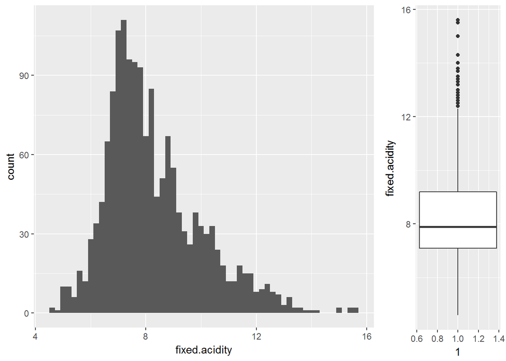

Most wines have a fixed acidity between 4 and 12 g / dm^3 with a mean of 8,32. The distribution is normal and a little bit right skewed. Outliers on the right. 1st Quartile = 7.1 g / dm^3 Median = 7.9 g / dm^3 3rd Quartile = 9.2 g / dm^3 Mean = 8.316 g / dm^3

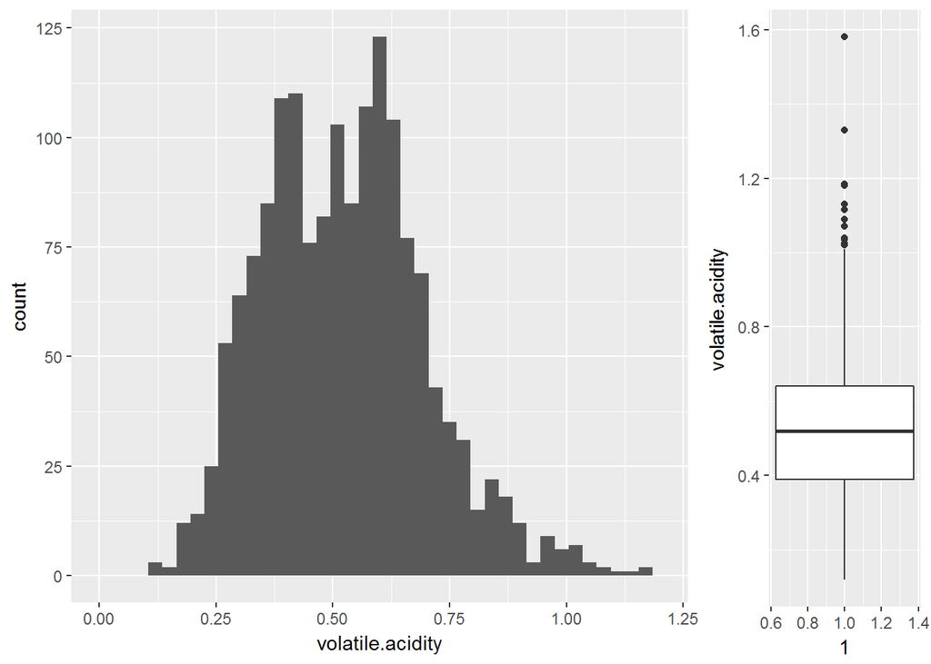

Volatile acidity seems to behave like a bimodal distribution with most values between 0.2 and 1.00 g / dm^3, and with a peak at around 0.4 and 0.6 g / dm^3. Outliers on the right. 1st Quartile = 0.39 g / dm^3 Median = 0.52 g / dm^3 3rd Quartile = 0.64 g / dm^3 Mean = 0.5274 g / dm^3

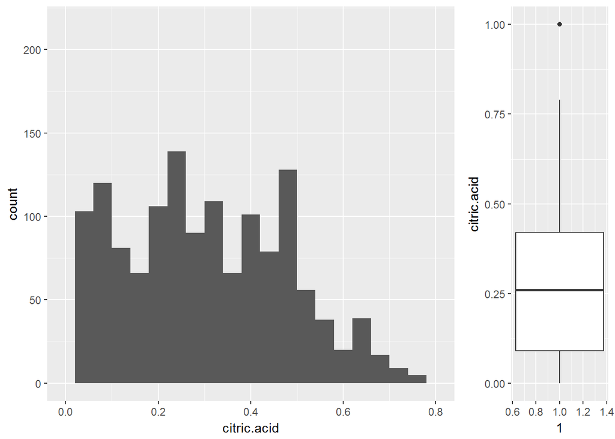

The citric acid is more or less evenly distributed between 0.02 and 0.5 g / dm^3 and then drops lineair until 0.78 g / dm^3. 1st Quartile = 0.09 g / dm^3 Median = 0.26 g / dm^3 3rd Quartile = 0.42 g / dm^3 Mean = 0.2698 g / dm^3

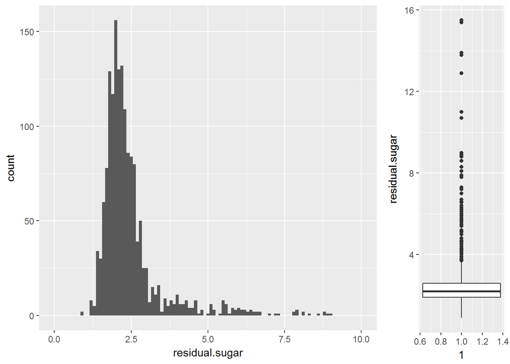

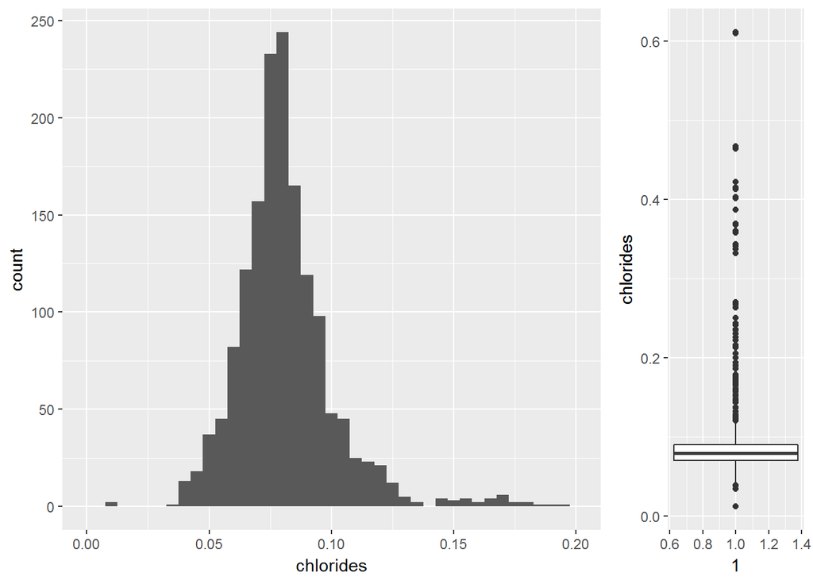

Chlorides is a normal distribution a little bit skewed on the right. Most values between 0.04 and 0.13 g / dm^3. 1st Quartile = 0.07 g / dm^3 Median = 0.079 g / dm^3 3rd Quartile = 0.09 g / dm^3 Mean = 0.0875 g / dm^3

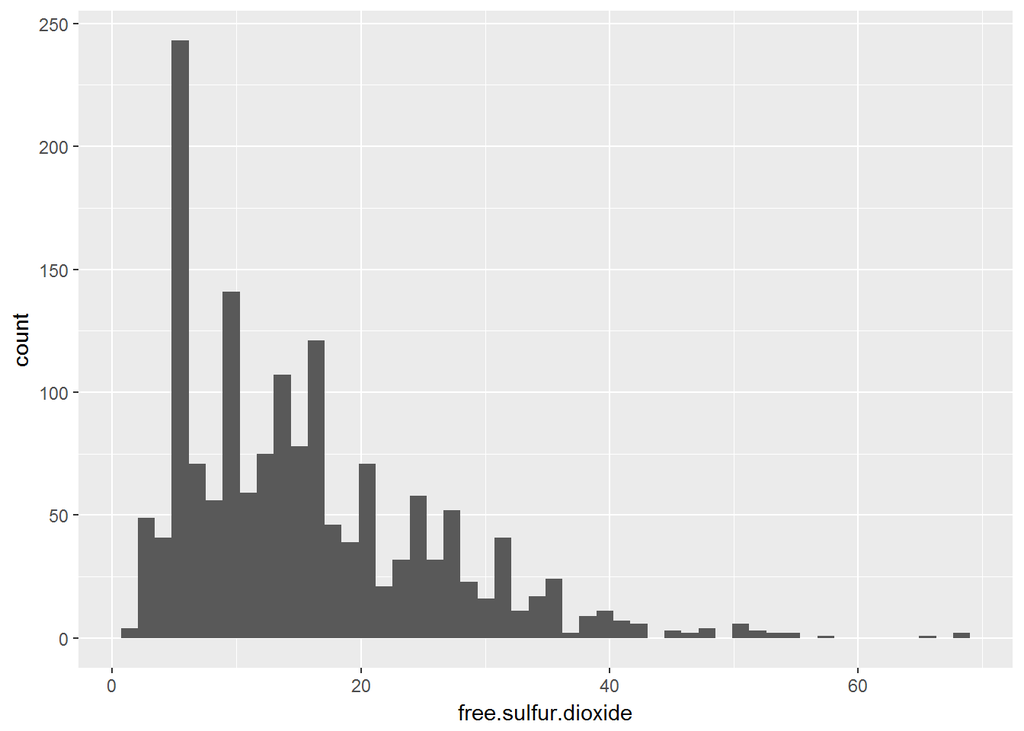

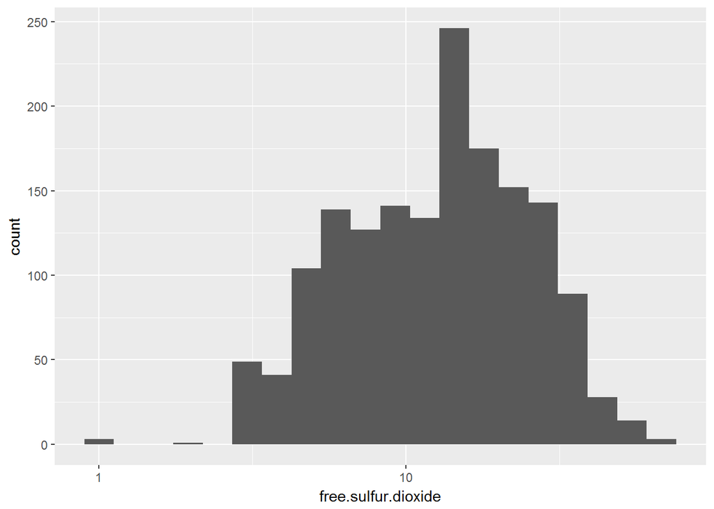

1st Quartile = 7.0 mg / dm^3 Median = 13.0 mg / dm^3 3rd Quartile = 21.0 mg / dm^3 Mean = 15.73 mg / dm^3

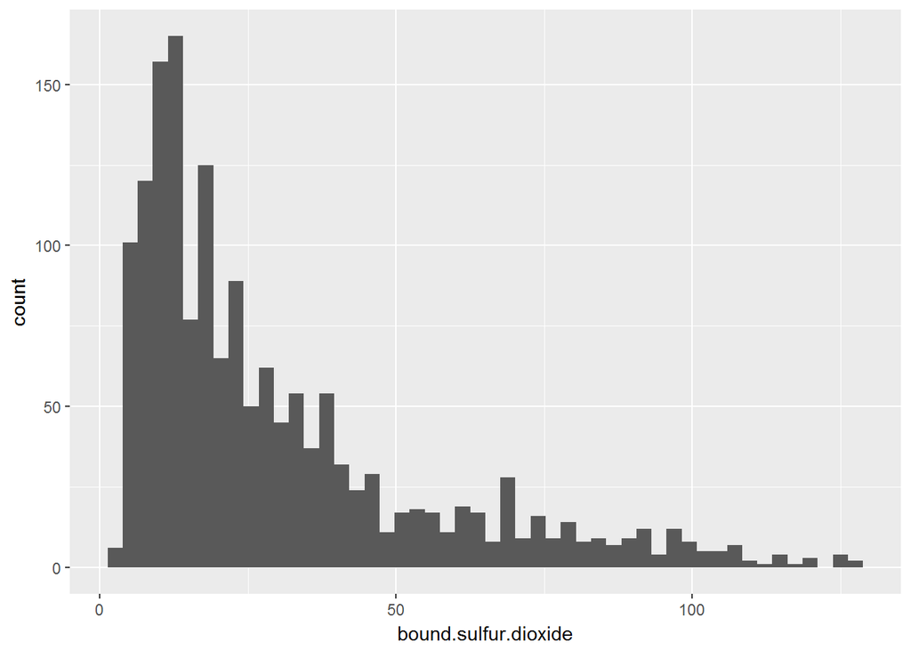

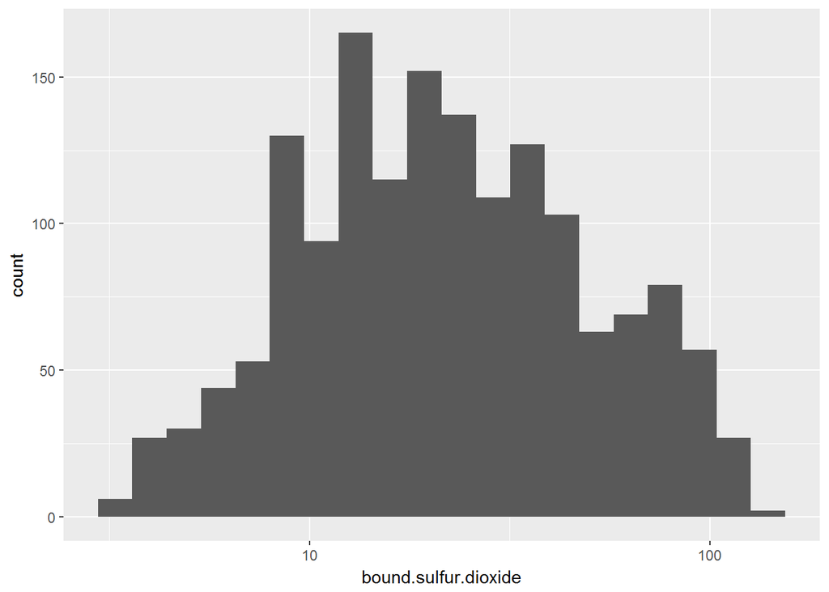

1st Quartile = 12.0 mg / dm^3 Median = 21.0 mg / dm^3 3rd Quartile = 39.0 mg / dm^3 Mean = 29.94 mg / dm^3

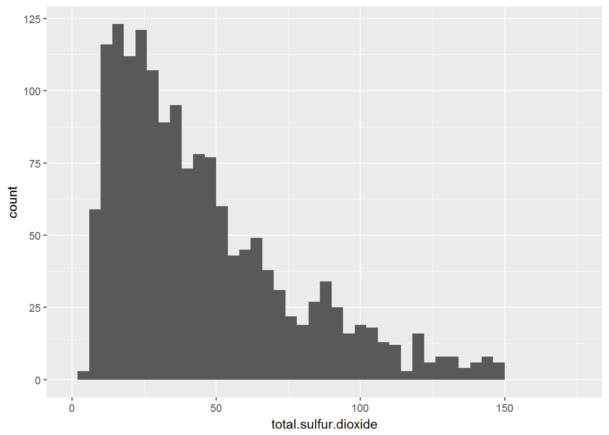

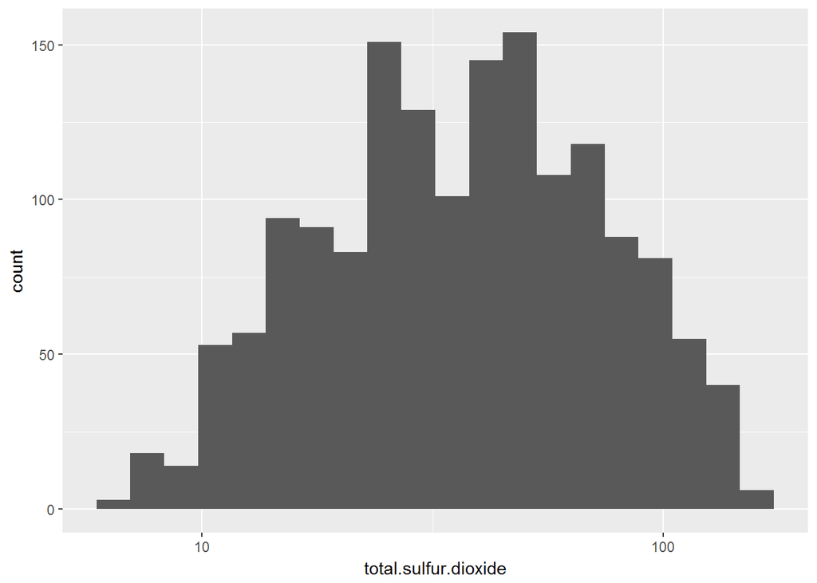

1st Quartile = 22.0 mg / dm^3 Median = 38.0 mg / dm^3 3rd Quartile = 61.0 mg / dm^3 Mean = 45.67 mg / dm^3

Free, bound and total sulfur dioxide have a normal distribution on a log 10 scale.

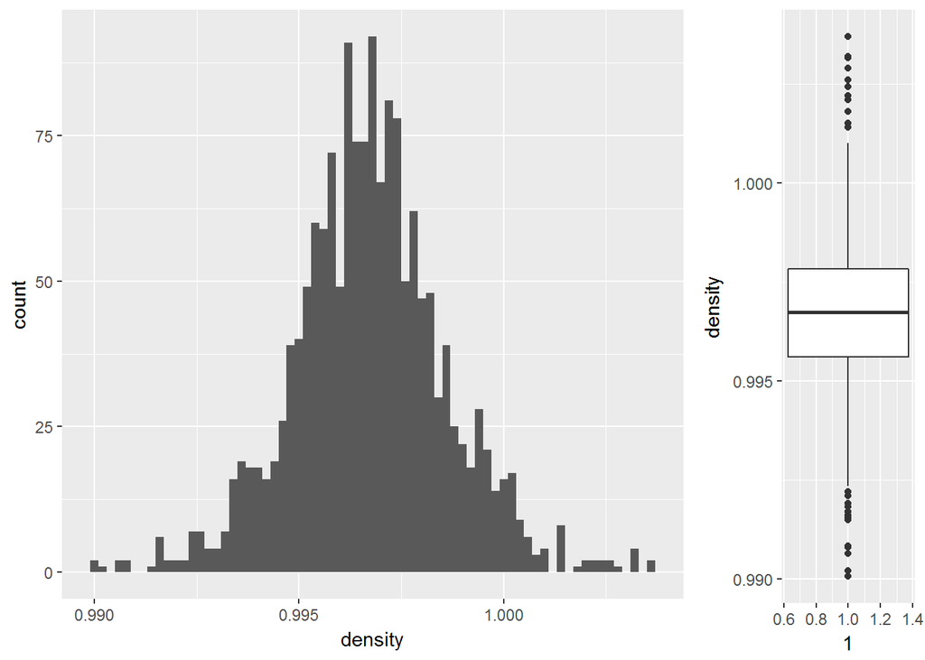

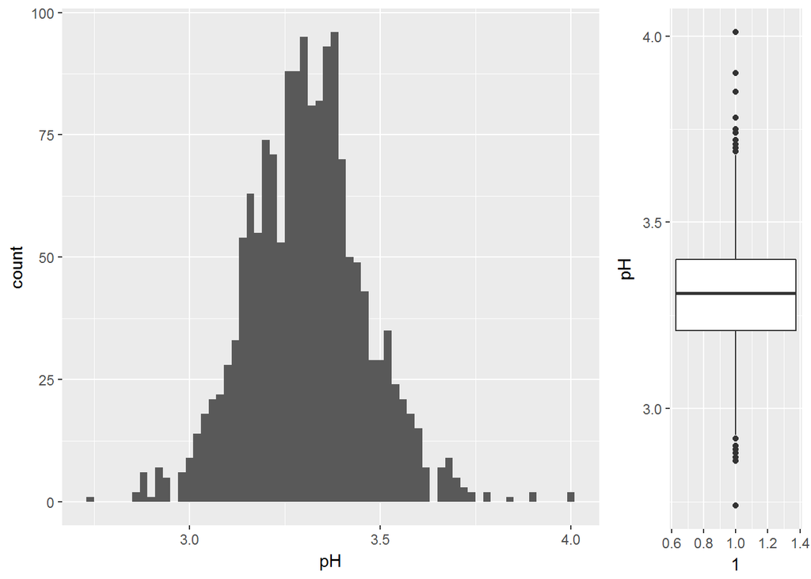

The mean and median are almost the same here.Nice normal distribution. 1st Quartile = 3.21 Median = 3.310 3rd Quartile = 3.4 Mean = 3.312

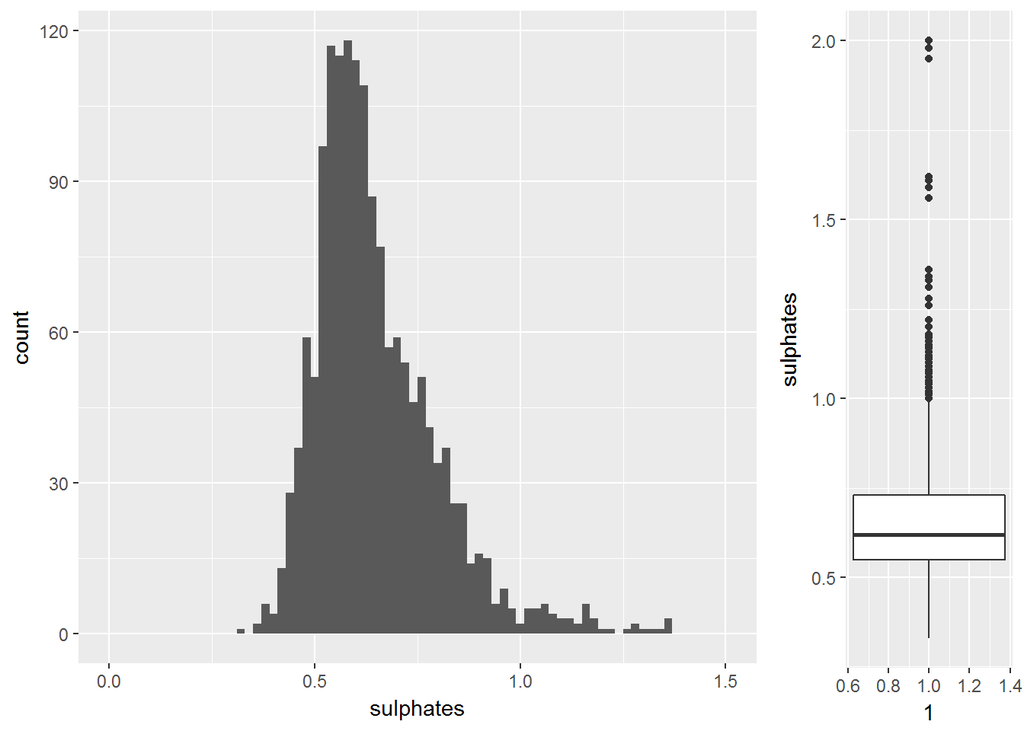

Sulphates is a normal distribution a little bit skewed on the right. Most values between 0.4 and 1.0 g / dm^3. 1st Quartile = 0.55 g / dm^3 Median = 0.62 g / dm^3 3rd Quartile = 0.73 g / dm^3 Mean = 0.6582 g / dm^3

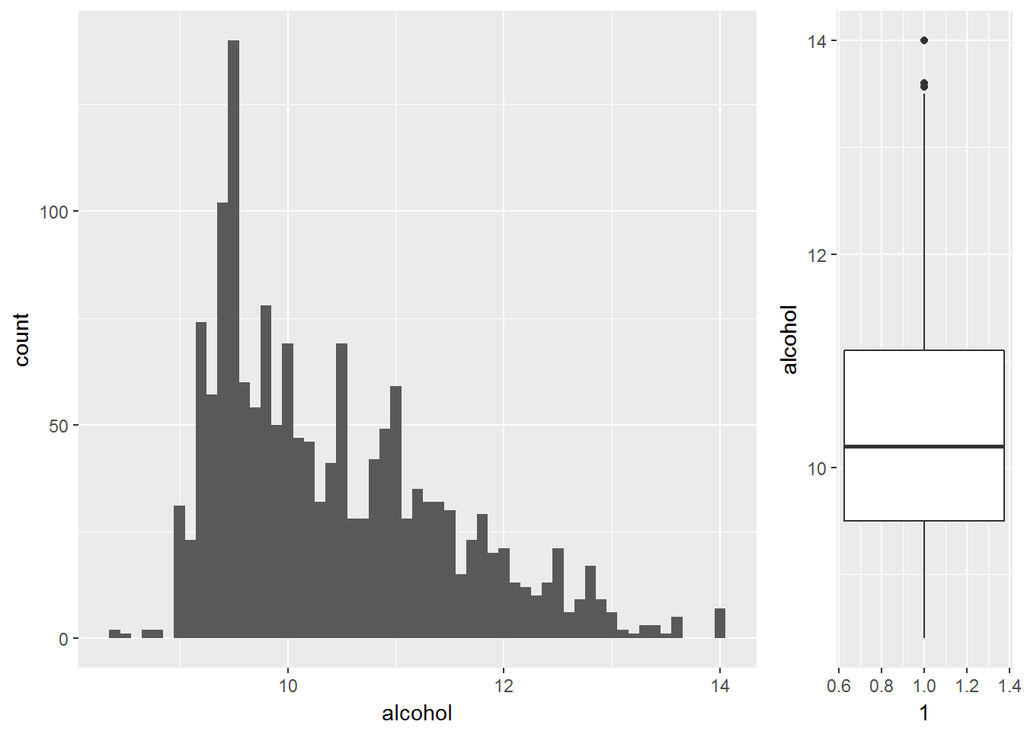

Alcohol percentage is between 8.4% and 14%. It quickly builds up to a peak at 9.5% and then drops lineairly to zero at around 14%. This is probably due to the fact that alcohol stops the yeasting proces that is responsible for the creation of alcohol. I wonder how the relation between alcohol and residual sugar looks, since the alcohol is a product of the fermentation of the original sugar. 1st Quartile = 9.5% Median = 10.2% 3rd Quartile = 11.1% Mean = 10.42%

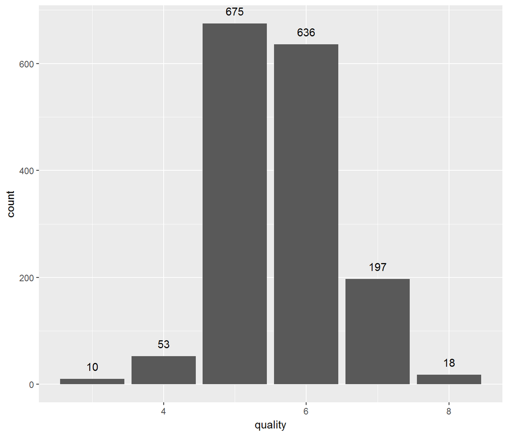

The majority of the wines have a score 5 or 6. I wonder how the wines that score a 3 or 8 differ from the majority. 1st Quartile = 5 Median = 6 3rd Quartile = 6

# Univariate Analysis

### What is the structure of your dataset?

All variables except quality are quantitive, continuous variables. Quality is an ordered variable with the following levels from worst to best: 3, 4, 5, 6, 7, 8.

Other observations:

- Sulfur dioxides have a normal distribution on a log10 scale
- Citric acid is more or less evenly distributed between 0.02 and 0.5 g / dm^3 and then drops lineair until 0.78 g / dm^3.
- Alcohol percentage quickly builds from 9 percent up to a peak at 9.5 percent and then drops lineairly to zero at around 14 percent.
- Volatile acidity seems to behave like a bimodal distribution.
- The mean and the median are almost equal for Ph and density.
- All other continuous variables have a normal distribution with some skewness.
- 82.5 % of the wines have a quality of 5 or 6. 1,75% has a quality of 3 or 8.

### What is/are the main feature(s) of interest in your dataset?

The main feature in the dataset is quality. I would like to determine Which chemical properties influence the quality of red wines. I expect that quality is at least determined by the right combination of sweetness (residual sugar and alcohol) and sourness (fixe and volatile acidity, citric acid and PH).

### What other features in the dataset do you think will help support your investigation into your feature(s) of interest?

The relation between alcohol and residual sugar is interesting because alcohol is formed during fermentation of sugar. The remaining sugar influences the sweetness of the wine. Another important taste influencer is acidity expressed in the three types of acid(ity) and PH. Finally the tanin determines the dryness. Tannin is not measured, but just like free sulfur dioxide, it acts as an anti oxidant. Lower levels of free sulfur dioxide could indicate higher (not measured) levels of tannin.

### Did you create any new variables from existing variables in the dataset?

I created bound.sulfur.dioxide by subtracting free.sulfur.dioxide from total.sulfur.dioxide. At first I factorised quality with “#RW$quality<-factor(RW$quality, levels=c(3,4,5,6,7,8), ordered = TRUE)”, but changed it back because it gave errors with the cor function when I wanted to correlate quality with the other fields.

### Of the features you investigated, were there any unusual distributions?

# Bivariate Plots Section

```
##                      fixed.acidity volatile.acidity  citric.acid
## fixed.acidity           1.00000000     -0.266185230  0.675901595
## volatile.acidity       -0.26618523      1.000000000 -0.559623682
## citric.acid             0.67590159     -0.559623682  1.000000000
## residual.sugar          0.11767315      0.017252221  0.133416312
## chlorides               0.09306831      0.059376079  0.206087779
## free.sulfur.dioxide    -0.15508084     -0.011747875 -0.072897716
## total.sulfur.dioxide   -0.12026768      0.079374876  0.009043528
## density                 0.67301696      0.009854474  0.373953402
## pH                     -0.68599389      0.237152337 -0.538272476
## sulphates               0.18180808     -0.264969498  0.314960461
## alcohol                -0.07226262     -0.195549619  0.103030221
## quality                 0.13011790     -0.388004481  0.226010134
## bound.sulfur.dioxide   -0.08416328      0.101765469  0.040581656
##                      residual.sugar    chlorides free.sulfur.dioxide
## fixed.acidity           0.117673151  0.093068310        -0.155080843
## volatile.acidity        0.017252221  0.059376079        -0.011747875
## citric.acid             0.133416312  0.206087779        -0.072897716
## residual.sugar          1.000000000  0.062408851         0.157180103
## chlorides               0.062408851  1.000000000         0.008134294
## free.sulfur.dioxide     0.157180103  0.008134294         1.000000000
## total.sulfur.dioxide    0.161241576  0.056959878         0.664261430
## density                 0.374601749  0.198383154        -0.020778829
## pH                     -0.075137239 -0.268280915         0.079871602
## sulphates               0.006307556  0.370205252         0.056282252
## alcohol                 0.027379378 -0.221213520        -0.075768620
## quality                 0.005886893 -0.126682538        -0.053673510
## bound.sulfur.dioxide    0.133388466  0.066317529         0.406737881
##                      total.sulfur.dioxide      density          pH
## fixed.acidity                -0.120267682  0.673016962 -0.68599389
## volatile.acidity              0.079374876  0.009854474  0.23715234
## citric.acid                   0.009043528  0.373953402 -0.53827248
## residual.sugar                0.161241576  0.374601749 -0.07513724
## chlorides                     0.056959878  0.198383154 -0.26828091
## free.sulfur.dioxide           0.664261430 -0.020778829  0.07987160
## total.sulfur.dioxide          1.000000000  0.088232101 -0.04724572
## density                       0.088232101  1.000000000 -0.35132410
## pH                           -0.047245720 -0.351324097  1.00000000
## sulphates                     0.053533099  0.143941779 -0.19980829
## alcohol                      -0.236058784 -0.498292115  0.21745458
```

[output cut: 15 more lines]

```
## bound.sulfur.dioxide  0.042625870 -0.25780305 -0.230934658
##                      bound.sulfur.dioxide
## fixed.acidity                 -0.08416328
## volatile.acidity               0.10176547
## citric.acid                    0.04058166
## residual.sugar                 0.13338847
## chlorides                      0.06631753
## free.sulfur.dioxide            0.40673788
## total.sulfur.dioxide           0.95305541
## density                        0.11624842
## pH                            -0.09009479
## sulphates                      0.04262587
## alcohol                       -0.25780305
## quality                       -0.23093466
## bound.sulfur.dioxide           1.00000000
```

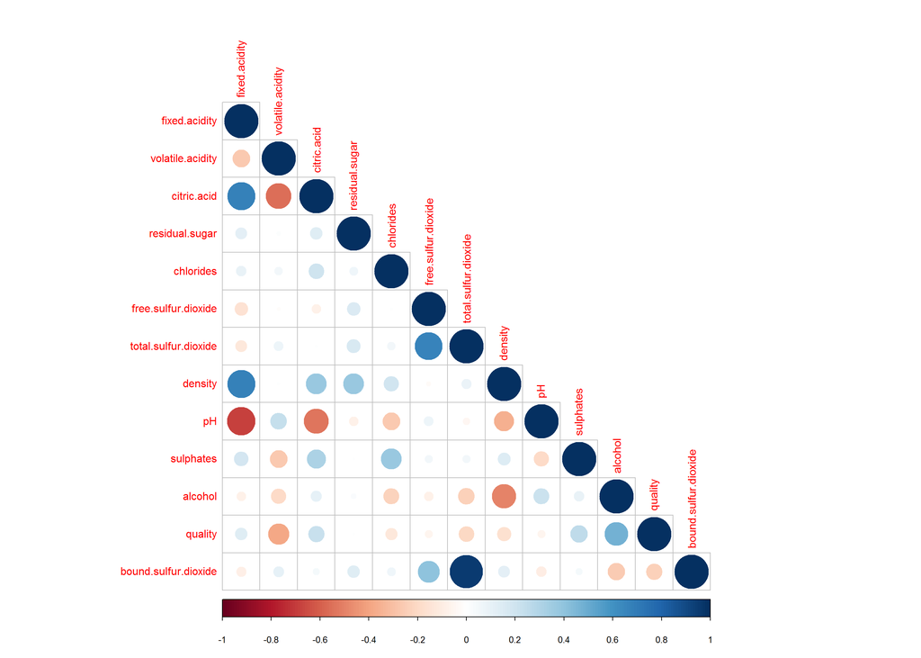

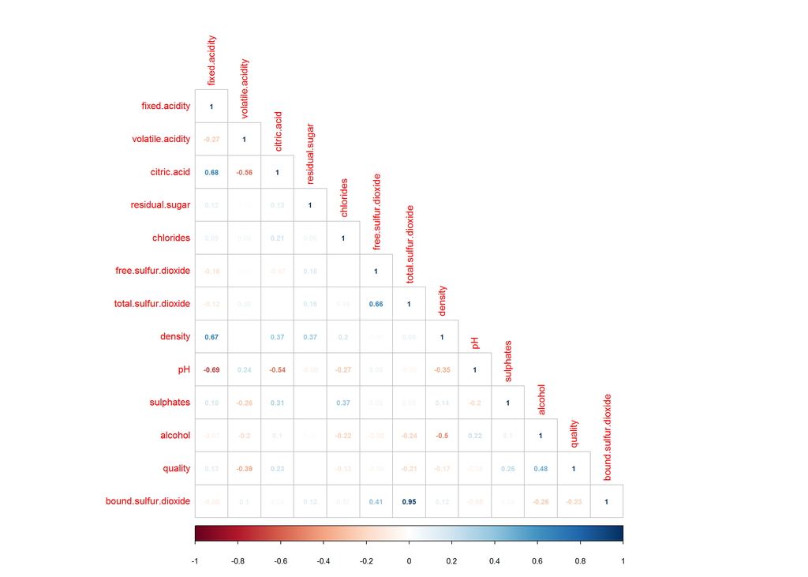

I used the following guidelines for correlation: If > 0,7 = Large, 0,7 - 0,5 is Moderate, 0,5 - 0,3 small but meaningfull.

Based on this I see a moderate positive correlation between:  
* fixed acidity and citric acid  
* fixed acidity and density

I see a moderate negative correlation between:  
* fixed acidity and PH  
* volatile acidity and citric acid  
* citric acid and PH  
* alcohol and density

I see meaningfull positive correlation between:  
* citric acid and density  
* citric acid and sulphates  
* residual sugar and density  
* chlorides and sulphates  
* free sulfur dioxide and bound sulfur dioxode  
* quality and alcohol

I see meaningfull negative correlation between:  
* quality and volatile acidity  
* PH and density

I on purpose did not mention the correlation between bound and free sulfur dioxide on the one hand and total dioxide on the other hand.

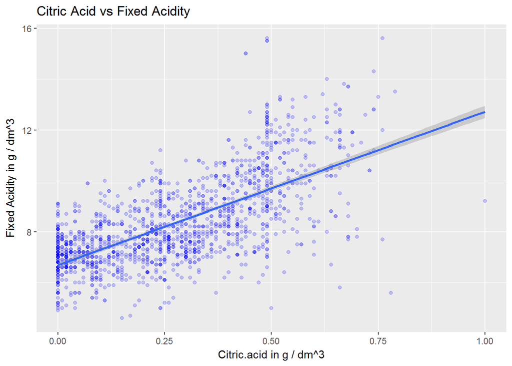

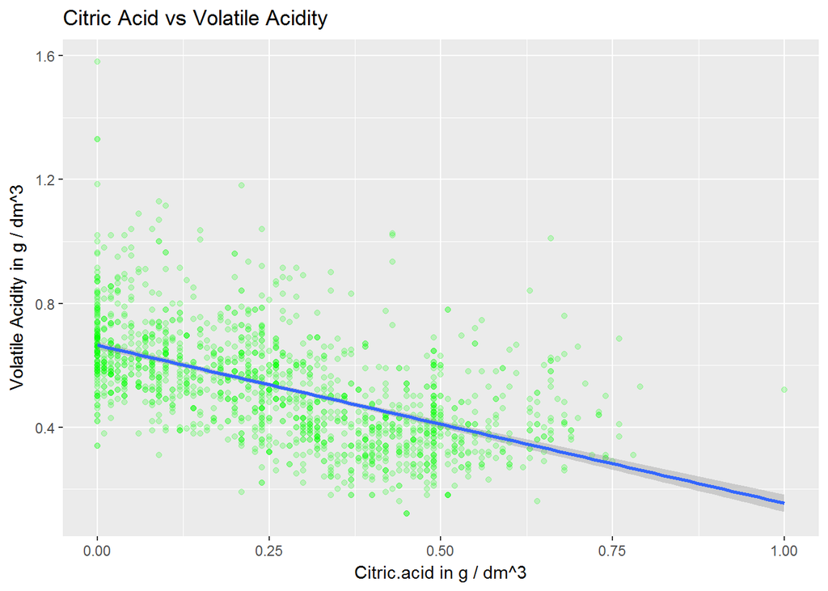

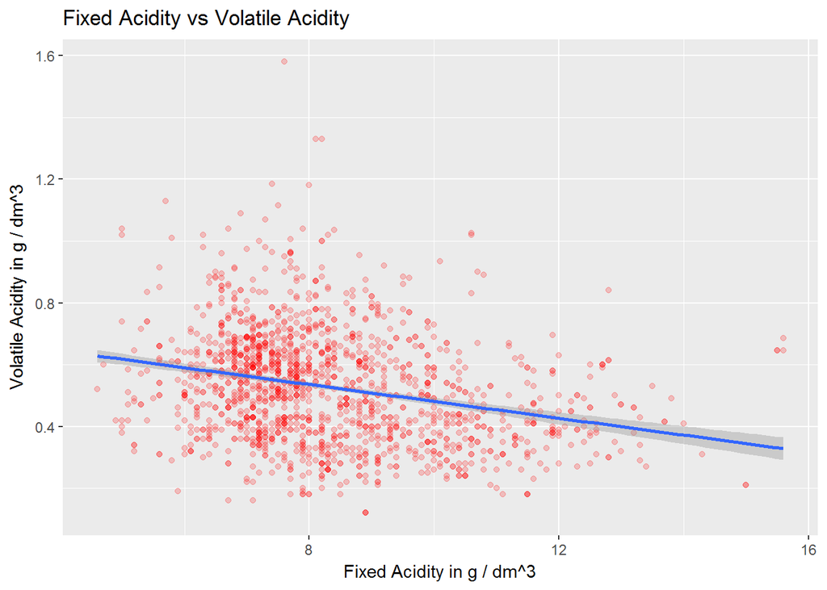

While citric acid and fixed acidity are strongly positively correlated (+0.68), volatile acidity is negatively correlated with the other two (-0.27 and -0.56).

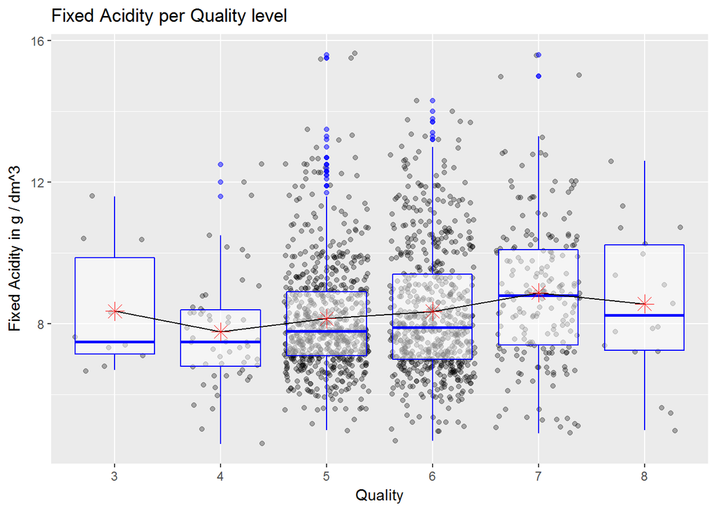

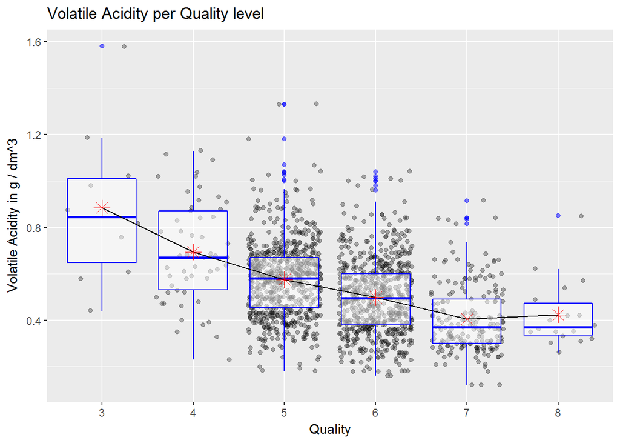

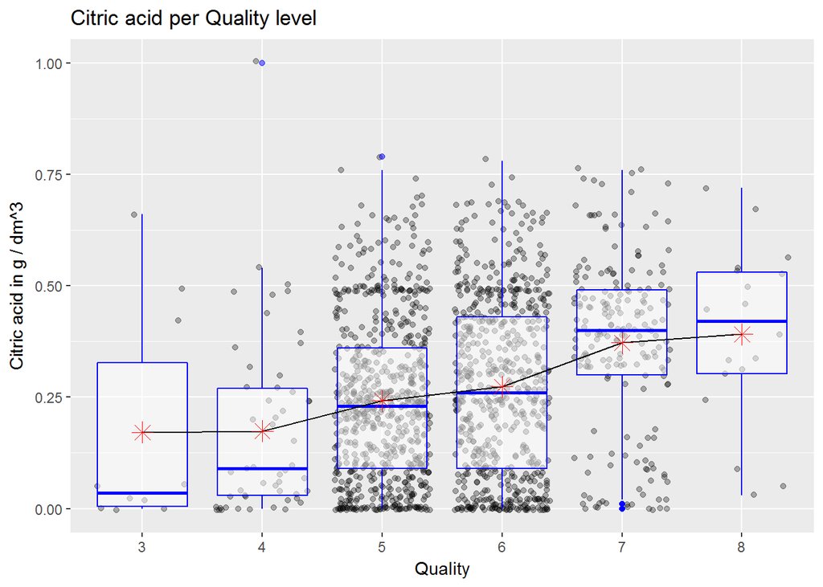

Volitale acidity has an almost lineair influence on quality, with no distinction between quality level 7 and 8. Citric acid’s influence on quality is not lineair , but the citric acid’s level makes jumps between every two quality levels. There are three groups: quality levels 3 and 4, 5 and 6, 7 and 8. Within the groups citric acid’s level is more or less stable, between the groups levels make a jump.

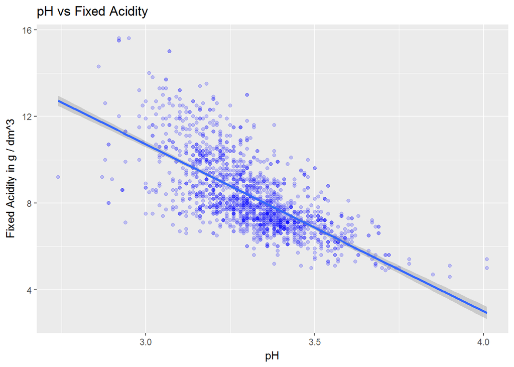

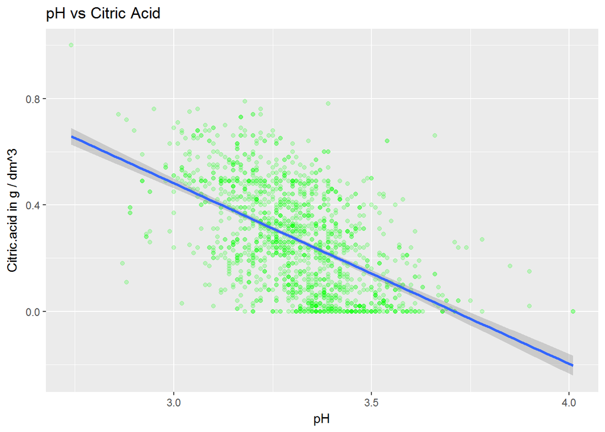

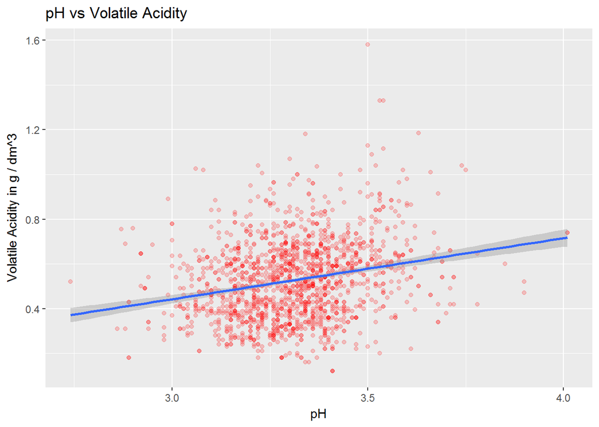

pH is very strongly influenced by fixed acidity (clear direction, close to the smooth line, correlation -0.69),a little bit less strong (data points more spread out) by citric acid (-0.54), and the least by volatile acidity (+0.24). More fixed acidity and citric acid add to the overal acidity taste, more volatile acidity to less overal acidity taste.

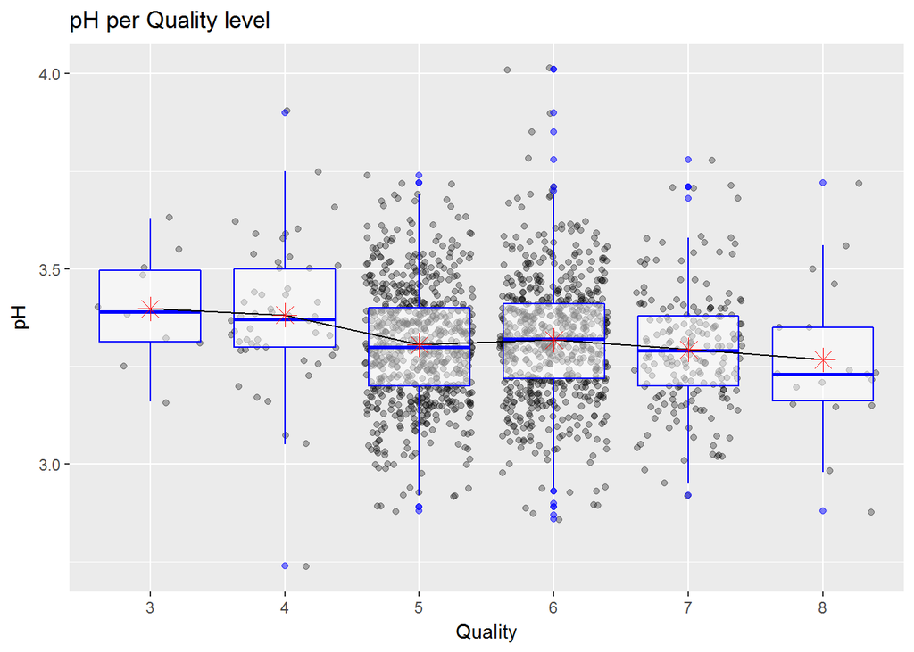

From the correlation information and the boxplots it is clear that acidity, acid and PH are strongly correlated to each other. But, is it the volatile acidity (-0.39) and the citric acid (+0.23) that are correlated to quality. The box plots for these two show that higher levels of citric acid and lower levels of volatile acid on average lead to a higher quality. What is also noticable, that for quality levels 7 and 8, there is hardly any difference. Maybe to discriminate between a 7 and 8, other factors play a more important role. For fixed acidity I don’t see significant differences on level 5 and 6 and no trend taking the other levels into account. I suppose this is because the the majority of measurements is on level 5 and 6. A higher fixed acidity does lead to a lower PH. Higher quality wines tend to lower PH levels.

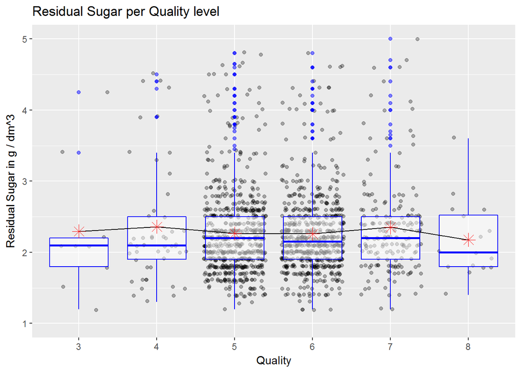

I cannot discover any relation between residual sugar and quality. The median for the various quality levels is not moving in a certain direction and there are lots of outliers for most quality levels.

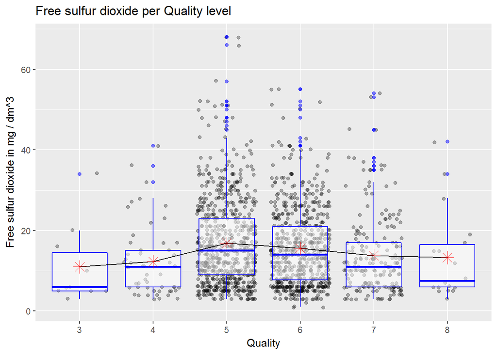